# Surveys

Beth Babcock

2025-10-27

```r
library(tidyverse)
theme_set(theme_bw())
```

### Simulated data for stratification

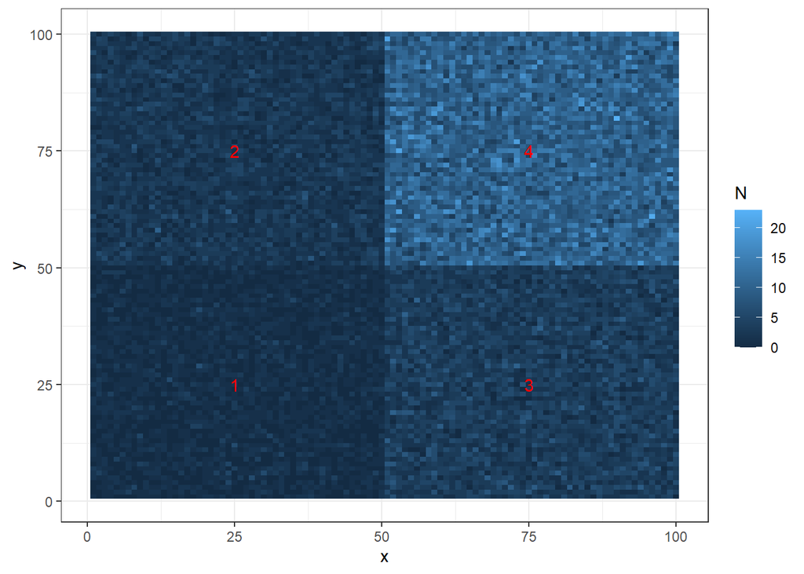

```r
set.seed(10)
meanVals<-c(1,2.4,3.5,10)
area<-expand.grid(x=1:100,y=1:100) %>%
  mutate(strata=case_when(x<=50&y<=50~1,
                          x<=50&y>50~2,
                          x>50&y<=50~3,
                          x>50&y>50~4),
         N=rpois(10000,meanVals[strata]))
ggplot(area,aes(x=x,y=y,fill=N))+
  geom_tile()+
  annotate("text",x=c(25,25,75,75),y=c(25,75,25,75),label=1:4,color="red")
```

Real population

```r
sum(area$N)
```

```
## [1] 42268
```

Make a simple random sample

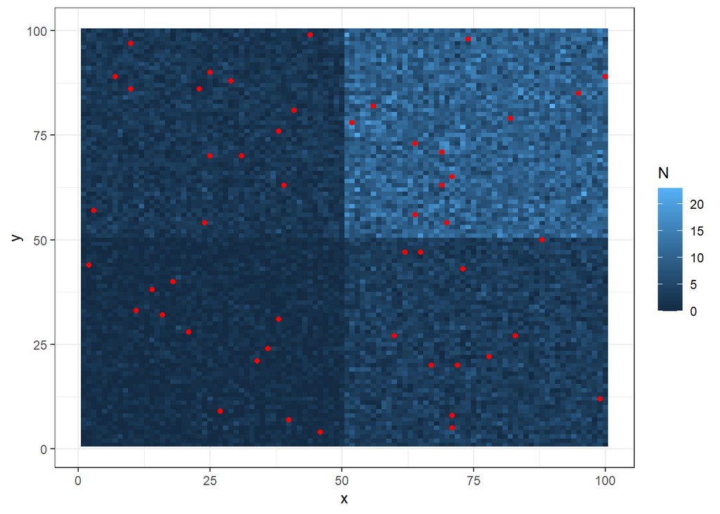

```r
n<-50
dataSimple<-sample(1:nrow(area),size=n,replace=FALSE)
ggplot(area,aes(x=x,y=y,fill=N))+
  geom_tile()+
  geom_point(data=area[dataSimple,],aes(x=x,y=y),color="red")
```

```r
simple<-area[dataSimple,] %>%
  summarize(meanCount=mean(N),
            seCount=sd(N)/sqrt(n()),
            n=n(),
            N=meanCount*nrow(area),
            seN=seCount*nrow(area),
            lci=N-2*seN,
            uci=N+2*seN)
simple %>% mutate(across(where(is.numeric),round,2))
```

```
##   meanCount seCount  n     N     seN      lci      uci
## 1       4.1    0.56 50 41000 5644.21 29711.57 52288.43
```

Stratified with same sample size

```r
SamplesPerStrata<-round(n*meanVals/sum(meanVals))  #variance=mean for Poisson
SamplesPerStrata
```

```
## [1]  3  7 10 30
```

```r
strataSample<-NULL
for(i in 1:4) strataSample<-
  c(strataSample,sample(which(area$strata==i),
                        size=SamplesPerStrata[i],
                        replace=FALSE))
table(area$strata[strataSample])
```

```
##
##  1  2  3  4
##  3  7 10 30
```

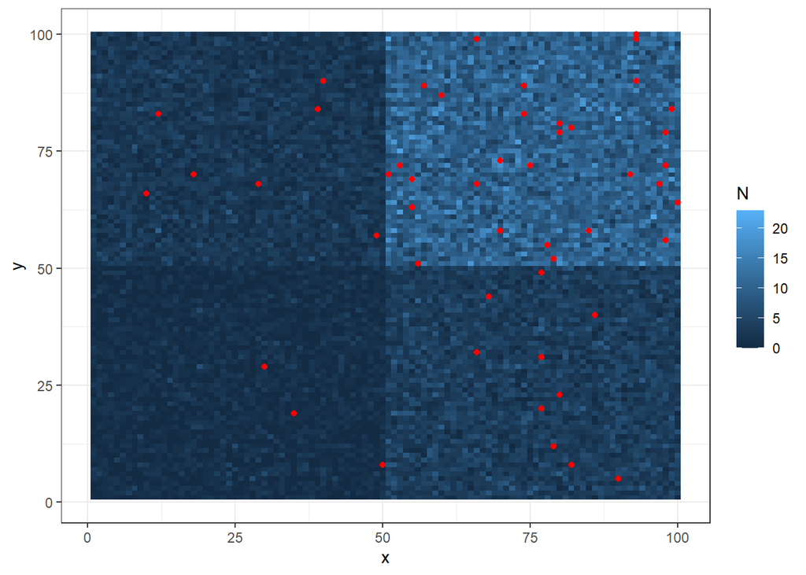

```r
ggplot(area,aes(x=x,y=y,fill=N))+
  geom_tile()+
  geom_point(data=area[strataSample,],aes(x=x,y=y),color="red")
```

```r
stratified<- area[strataSample,] %>%
  group_by(strata)%>%
  summarize(meanCount=mean(N),
            seCount=sd(N)/sqrt(n()),
            n=n(),
            area=nrow(area)/4,
            N=meanCount*area,
            seN=seCount*area) %>%
  ungroup()

stratified %>% mutate(across(where(is.numeric),round,2))
```

```
## # A tibble: 4 × 7
##   strata meanCount seCount     n  area      N   seN
##    <dbl>     <dbl>   <dbl> <dbl> <dbl>  <dbl> <dbl>
## 1      1      1.33    0.33     3  2500  3333.  833.
## 2      2      2.43    0.43     7  2500  6071. 1071.
## 3      3      2.3     0.45    10  2500  5750  1121.
## 4      4     10.4     0.58    30  2500 25917. 1446.
```

```r
stratTotal<-stratified %>% summarize(N=sum(N),
                        seN=sqrt(sum(seN^2)),
                        lci=N-2*seN,
                        uci=N+2*seN)
stratTotal %>% mutate(across(where(is.numeric),round,2))
```

```
## # A tibble: 1 × 4
##        N   seN    lci    uci
##    <dbl> <dbl>  <dbl>  <dbl>
## 1 41071. 2278. 36515. 45628.
```

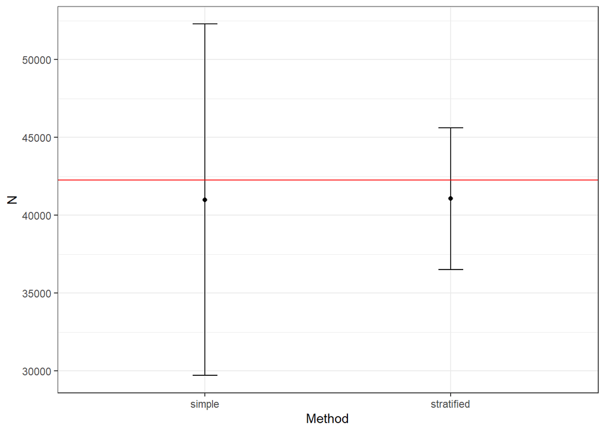

```r
bind_rows(list(simple=simple,
               stratified=stratTotal),
          .id="Method")%>%
  ggplot(aes(x=Method,y=N,ymin=lci,ymax=uci))+
  geom_point()+
  geom_errorbar(width=0.1)+
  geom_hline(yintercept=sum(area$N),color="red")
```

### Simple random sample and stratified random

Grand Banks Yellowtail Flounder in 2006 from Brad Stevens

```r
tows <- read.csv("GB_YTF_2006_Tows2.csv")
head(tows)
```

```
##   Cruise Stratum Tow Num Weight Season area
## 1 200604    1130   1   2   0.30 Spring 0.01
## 2 200604    1130   2   4   1.18 Spring 0.01
## 3 200604    1130   3   6   0.78 Spring 0.01
## 4 200604    1130   4   0   0.00 Spring 0.01
## 5 200604    1130   5   0   0.00 Spring 0.01
## 6 200604    1130   6   5   0.18 Spring 0.01
```

```r
strata<-read.csv("strata.csv")
strata
```

```
##   Stratum area
## 1    1130 2374
## 2    1140  656
## 3    1150  230
## 4    1160 2980
## 5    1170  360
## 6    1180  172
## 7    1190 2454
## 8    1200 1221
## 9    1210  424
```

```
## No summary function supplied, defaulting to `mean_se()`
```

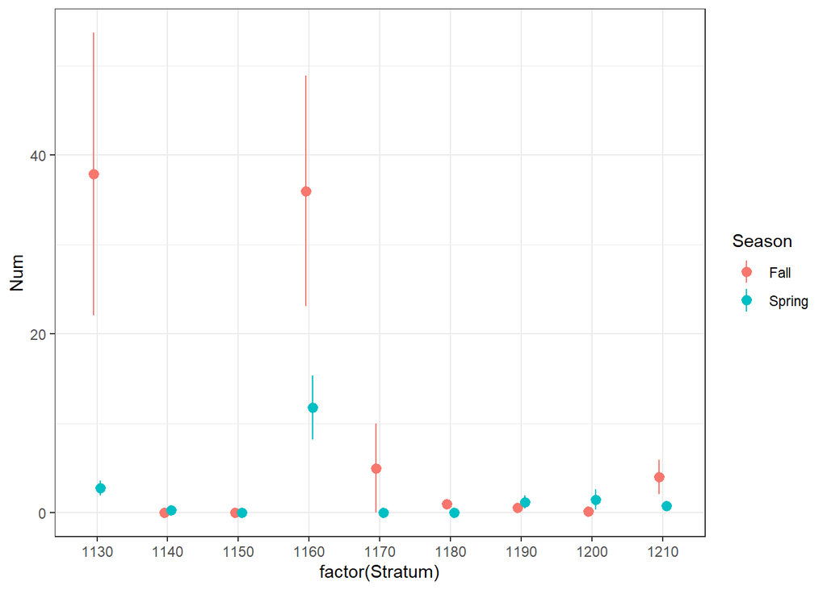

```r
ggplot(tows,aes(x=factor(Stratum),y=Num,color=Season))+
  stat_summary(position=position_dodge(width=0.2))
```

```r
with(tows,table(Season,Stratum))
```

```
##         Stratum
## Season   1130 1140 1150 1160 1170 1180 1190 1200 1210
##   Fall      8    3    1   20    3    1    9    6    4
##   Spring    9    3    1   20    3    1    9    6    4
```

Simple random sample in stratum 1160, spring only

```r
strataSum<-tows %>%
  filter(Season=="Spring",Stratum==1160)%>%
  group_by(Stratum) %>%
  summarize(meanCount=mean(Num),
            seCount=sd(Num)/sqrt(n()),
            n=n(),
            meanDensity=mean(Num/area),
            seDensity=sd(Num/area)/sqrt(n()),
            sampled.area=sum(area))
#Or, as tows are all the same area (0.01)
strataSum<-strataSum %>%
  mutate(meanDensity2=meanCount/0.01,
         seDensity2=seCount/0.01)
# Use total area to get total numbers
strataSum<-strataSum %>%
  mutate(N=meanDensity*2980,
         seN=seDensity*2980)
```

Total average density and total numbers across seasons and spatial stratas. Calculate totals per stratum, use left_join to add total areas to each stratum

```r
stratSeasonSum<-tows %>% group_by(Stratum,Season) %>%
  summarize(meanCount=mean(Num),
            seCount=sd(Num)/sqrt(n()),
            n=n(),
            meanDensity=mean(Num/area),
            seDensity=sd(Num/area)/sqrt(n()),
            sampled.area=sum(area)) %>%
  left_join(strata,by="Stratum") %>%
  mutate(N=meanDensity*area,
         seN=seDensity*area) %>%
  ungroup()
view(stratSeasonSum)
```

Some strata are understudied, so can’t be estimated. For now, fill in 0 for the variances to get the sum in each season

```r
TotalSeason<-stratSeasonSum %>%
  mutate(seN=replace_na(seN,0),
         seDensity=replace_na(seDensity,0)) %>%
  group_by(Season)%>%
  summarize(N=sum(N),
            seN=sqrt(sum(seN^2)),
            lciN=N-2*seN,
            uciN=N+2*seN,
            meanDensity=sum(meanDensity*area)/sum(area),
            seDensity=sqrt((sum(seDensity^2*area)/sum(area))))

TotalSeason
```

```
## # A tibble: 2 × 7
##   Season         N      seN     lciN      uciN meanDensity seDensity
##   <chr>      <dbl>    <dbl>    <dbl>     <dbl>       <dbl>     <dbl>
## 1 Fall   20243008. 5370655. 9501698. 30984319.       1862.     1005.
## 2 Spring  4697694. 1106130. 2485435.  6909953.        432.      198.
```

For comparison, unstratified sample in each season (not really correct)

```r
simpleSum<-tows %>%
  group_by(Season)%>%
  summarise(meanCount=mean(Num),
            seCount=sd(Num)/sqrt(n())) %>%
  mutate(N=meanCount*sum(strata$area)/0.01,
         seN=seCount*sum(strata$area)/0.01,
         lciN=N-2*seN,
         uciN=N+2*seN)
simpleSum
```

```
## # A tibble: 2 × 7
##   Season meanCount seCount         N      seN     lciN      uciN
##   <chr>      <dbl>   <dbl>     <dbl>    <dbl>    <dbl>     <dbl>
## 1 Fall       19.3     5.63 20971147. 6121854. 8727440. 33214854.
## 2 Spring      5.07    1.44  5513150  1565795. 2381560.  8644740.
```

Comparing estimates

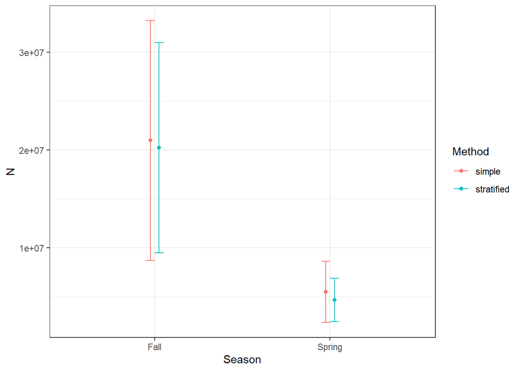

```r
bind_rows(list(simple=simpleSum,
               stratified=TotalSeason),.id="Method") %>%
  ggplot(aes(x=Season,y=N,ymin=lciN,ymax=uciN,color=Method,group=Method))+
  geom_errorbar(position=position_dodge(width=0.1),width=0.1)+
  geom_point(position=position_dodge(width=0.1))
```

In this case it doesn’t make much difference if you use simple or stratified

### Example 2. Shark bottom longline data

https://www.fisheries.noaa.gov/inport/item/29395 https://catalog.data.gov/dataset/shark-and-red-snapper-bottom-longline-survey

Strata: 9 – 55 m, 55 – 183 m, and 183 – 366 m, but we will ignore this for now

```r
setwd("C:/Users/Elizabeth A Babcock/Box/Shark BLL")
station<-read.csv("Station_Data.csv") %>%
  mutate(date=as.Date(DATE),
         year=year(date))%>%
  filter(year>2000)

catch<-read.csv("Catch_Data.csv")
head(catch)
```

```
##   CDID CID SID SEAMAPSTATION SAMPLEID        GENUS    SPECIES   BIOCODE SEX
## 1    1   2   1    081523BL04       NA   GALEOCERDO     CUVIER 108022201   F
## 2    2   2   2    081523BL04       NA   GALEOCERDO     CUVIER 108022201   F
## 3    3   2   3    081523BL04       NA   GALEOCERDO     CUVIER 108022201   F
## 4    4   2   4    091423BL01       NA CARCHARHINUS   LIMBATUS 108020205   F
## 5    5   2   5    091423BL01       NA      SPHYRNA   MOKARRAN 108040103   M
## 6    6   2   6    091423BL02       NA CARCHARHINUS BREVIPINNA 108020207   F
##    PCL SL   FL   TL DW LENGTH WGT INITIALCOND RELCOND FISHID
## 1 1970 NA 2182 2704 NA      M  NA           K       0  AL001
## 2  605 NA  670  938 NA      M 2.6           K       0  AL002
## 3  544 NA  600  842 NA      M 1.6           K       0  AL003
## 4 1100 NA 1230 1560 NA      M  NA           A       1  AL004
## 5 1100 NA 1220 1623 NA      M  NA           A       1  AL005
## 6  740 NA  810 1015 NA      M 4.5           D       0  AL006
##                     samples TAGNUMBER
## 1 Fin clip,Muscle,Vertebrae
## 2 Fin clip,Muscle,Vertebrae
## 3 Fin clip,Muscle,Vertebrae
## 4                  Fin clip  MSU01081
## 5                  Fin clip  MSU00686
## 6                  Fin clip
##                                                                      COMMENT
## 1 FC-461,many bony catfish fish remains in stomach and crabs,no weight taken
## 2                                                                     FC-462
## 3                                                                     FC-463
## 4                                                     FC-493,no weight taken
## 5                                                     FC-494,no weight taken
## 6                                                                     FC-495
```

Make a new column for species and count catch by species

```r
catchSum<-catch %>%
  mutate(Species=paste(GENUS,SPECIES)) %>%
  filter(Species %in% c("RHIZOPRIONODON TERRAENOVAE","LUTJANUS CAMPECHANUS"))%>%
  group_by(SEAMAPSTATION,CID,Species) %>%
  summarize(count=n())%>%
  pivot_wider(names_from=Species,values_from=count,values_fill = 0)
head(catchSum)
```

```
## # A tibble: 6 × 4
## # Groups:   SEAMAPSTATION, CID [6]
##   SEAMAPSTATION   CID `LUTJANUS CAMPECHANUS` `RHIZOPRIONODON TERRAENOVAE`
##   <chr>         <int>                  <int>                        <int>
## 1 030413BL01       22                      5                           24
## 2 030413BL02       22                     10                           32
## 3 030413BL03       22                      6                           17
## 4 030513BL01       22                      0                            6
## 5 030513BL02       22                      0                            1
## 6 030513BL03       22                      0                            1
```

```r
StationData<-left_join(station,catchSum,by=c("SEAMAPSTATION","CID"))
StationData<-StationData %>%
  mutate(redSnapper=replace_na(`LUTJANUS CAMPECHANUS`,0),
         AtlSharpnose=replace_na(`RHIZOPRIONODON TERRAENOVAE`,0))
```

Get annual mean numbers

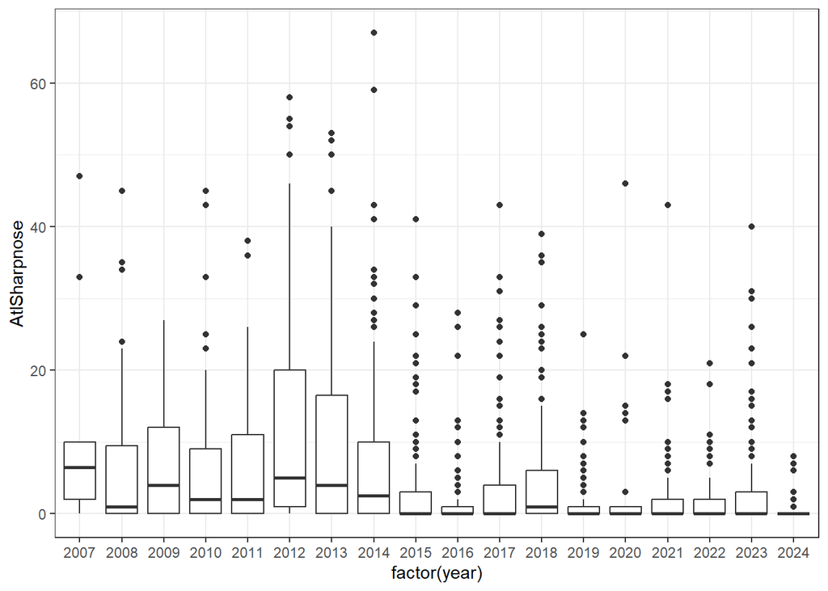

```r
ggplot(StationData,aes(x=factor(year),y=AtlSharpnose))+
  geom_boxplot()
```

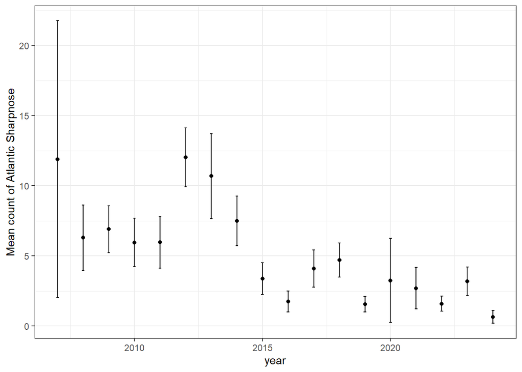

```r
yearSum<-StationData %>%
  group_by(year) %>%
  summarize(meanAS=mean(AtlSharpnose),
            seAS=sd(AtlSharpnose)/sqrt(n()))
ggplot(yearSum,aes(x=year,y=meanAS,ymin=meanAS-2*seAS,ymax=meanAS+2*seAS))+
  geom_point()+
  geom_errorbar(width=0.1)+
  ylab("Mean count of Atlantic Sharpnose")
```

### Distance sampling

https://distancesampling.org/Distance/articles/lines-distill.html

https://distancesampling.org/Distance/articles/web-only/points/pointtransects-distill.html

```r
library(Distance)
```

Line transect with wrens

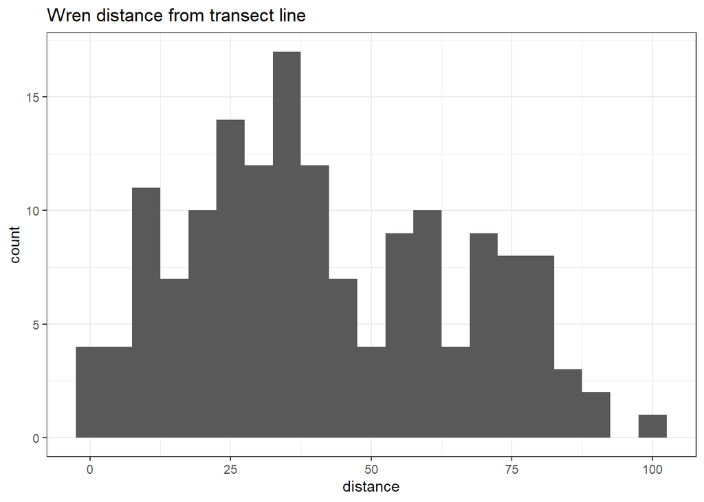

```r
data(wren_lt)
ggplot(wren_lt,aes(x=distance))+
  geom_histogram(binwidth=5)+
  ggtitle("Wren distance from transect line")
```

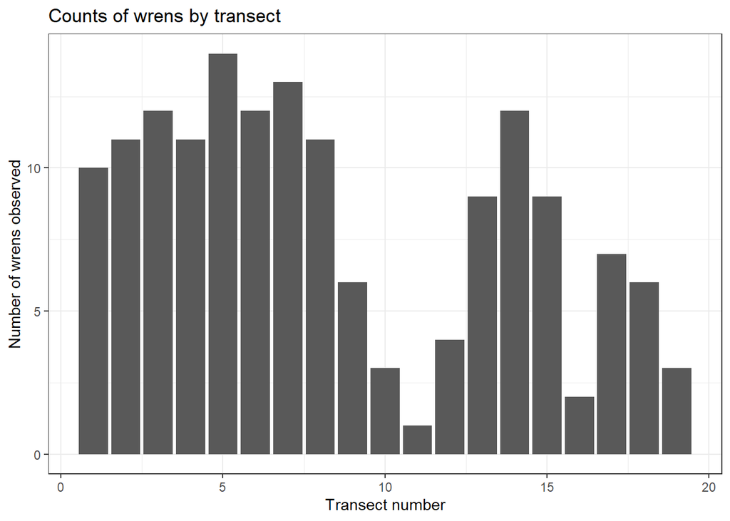

```r
ggplot(wren_lt,aes(x=as.numeric(Sample.Label)))+
  geom_bar()+
  labs(x="Transect number",
       y="Number of wrens observed",
       title="Counts of wrens by transect")
```

```r
head(wren_lt)
```

```
##   Region.Label Area Sample.Label Effort object distance Study.Area
## 1     Montrave 33.2            1  0.416      5       15 Montrave 4
## 2     Montrave 33.2            1  0.416      6       80 Montrave 4
## 3     Montrave 33.2            1  0.416      7       35 Montrave 4
## 4     Montrave 33.2            1  0.416      8       55 Montrave 4
## 5     Montrave 33.2            1  0.416     12       12 Montrave 4
## 6     Montrave 33.2            1  0.416     13       75 Montrave 4
```

Area is the total hectares in the study area. Effort is the length (km) of the transect. Distance is in m. Convert_units function gives units of distance, transect length and area.

```r
conversion.factor<-convert_units("meter", "kilometer", "hectare")
wren.hn <- ds(data=wren_lt,
              key="hn",
              adjustment=NULL,
              convert_units=conversion.factor)
```

```
## Fitting half-normal key function
```

```
## AIC= 1418.188
```

```r
summary(wren.hn)
```

```
##
## Summary for distance analysis
## Number of observations :  156
## Distance range         :  0  -  100
##
## Model       : Half-normal key function
## AIC         :  1418.188
## Optimisation:  mrds (nlminb)
##
## Detection function parameters
## Scale coefficient(s):
##             estimate        se
## (Intercept) 4.105816 0.1327744
##
##                       Estimate          SE         CV
## Average p             0.685037  0.05678821 0.08289802
## N in covered region 227.724931 21.47275208 0.09429250
##
## Summary statistics:
##     Region Area CoveredArea Effort   n  k       ER    se.ER      cv.ER
## 1 Montrave 33.2       193.2   9.66 156 19 16.14907 1.226096 0.07592366
##
## Abundance:
##   Label Estimate       se        cv     lcl     ucl       df
## 1 Total 39.13286 4.399007 0.1124121 31.3023 48.9223 74.24595
##
## Density:
##   Label Estimate        se        cv       lcl      ucl       df
## 1 Total   1.1787 0.1325002 0.1124121 0.9428403 1.473563 74.24595
```

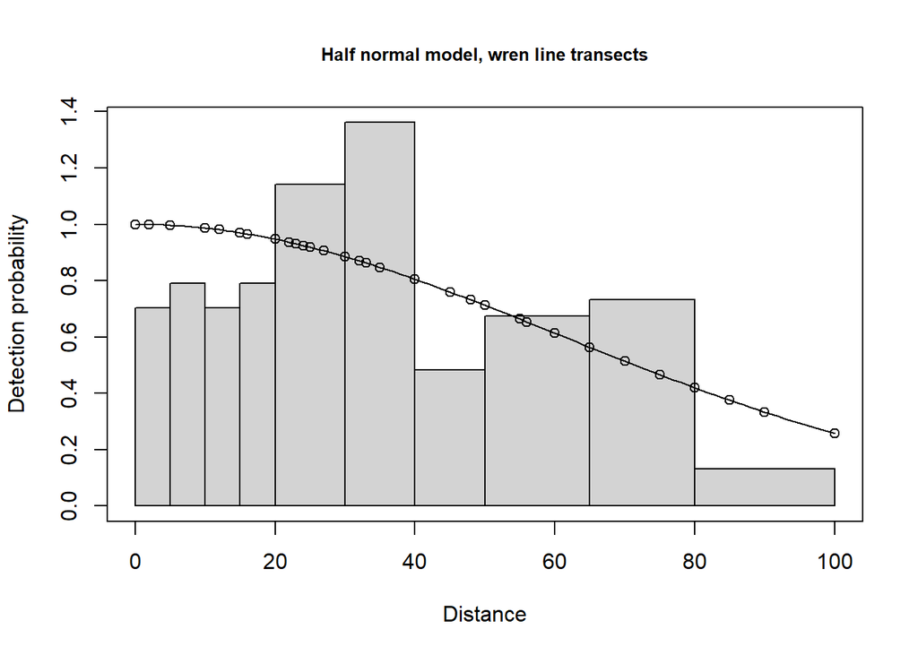

```r
cutpoints <- c(0,5,10,15,20,30,40,50,65,80,100)
plot(wren.hn, breaks=cutpoints, main="Half normal model, wren line transects")
```

Try other functions

```r
wren.unif.cos <- ds(wren_lt, key="unif", adjustment="cos", convert_units=conversion.factor)
```

```
## Starting AIC adjustment term selection.
```

```
## Fitting uniform key function
```

```
## AIC= 1436.813
```

```
## Fitting uniform key function with cosine(1) adjustments
```

```
## AIC= 1421.634
```

```
## Fitting uniform key function with cosine(1,2) adjustments
```

```
## AIC= 1417.792
```

```
## Fitting uniform key function with cosine(1,2,3) adjustments
```

```
## AIC= 1416.431
```

```
## Fitting uniform key function with cosine(1,2,3,4) adjustments
```

```
## AIC= 1416.959
```

```
##
## Uniform key function with cosine(1,2,3) adjustments selected.
```